# Practical: Poisson and NB regression

Physalia workshop on GLMs

Bert van der Veen

# Background

Yesterday, we focused on binomial regression with either 1) a probit link or 2) a logit link. Binomial regression is suitable for counts of successes of failures, or more generally when we are modeling counts as part of a total. However, there are plenty of cases when there is no real total. When such a critical property of a distribution or model does not align with the data we observe, we switch the model we use to better accommodate our data.

When the counts have no upperbound, such as with stars in the night sky, or grains of sand on a beach, we use Poisson regression. In Poisson regression, we allow the counts to be unbounded, but still require the prediction to be larger than zero. To make sure of that, Poisson regression uses the log link function. Let’s simulate an example with two continuous predictor variables to demonstrate this:

```r
set.seed(123)
n <- 200
x1 <- runif(n, 0, 3)
x2 <- runif(n, -1, 1)
eta <- 1+x1 - 0.3*x2
lambda <- exp(eta)
(y <- rpois(n, lambda))
```

```
##   [1] 14 16  8 37 38  2 18 44 13 12 49 13 30 11  7 45  5  9  4 38 44 12 18 55 28
##  [26] 22 12  9  8  4 38 41 16 33  5  7 35  4  9  0  2 10  8  9  8  1  3  9  4 36
##  [51]  1 11 21  1 16  3  4 24 34 11 13  5  7  6 25  5 39 32 28 14 31 31 28  1 11
##  [76]  4  9 17 12  5  3 28  5 32  3 11 68 49 50  1  8 28 11 17  8  4 26  7 14 15
## [101] 13 10 10 49 14 46 47 23  5  8 39  7  2 70 22  2  8 62 15  2 24 10 12  6 17
## [126] 79  4  4  1 15 20 41 17 14 17 18 32 24 51  6  8 14  2  6 38  9  1  4  6 27
## [151] 35  5 13  4  4  4 17  6 14  4 14 11 18 15  9 11 29  3 11  6 14  3 22 31 28
## [176] 11  6 17 44 11 18  3 23  6 20 11 10 18 39 51  3  7 51 12 49 11 13 27  4  9
```

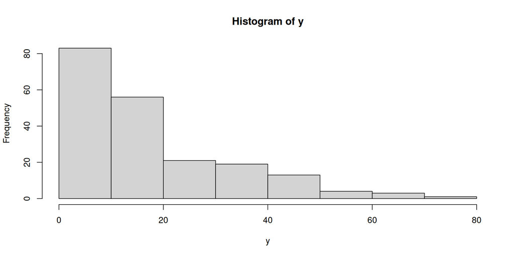

```r
hist(y)
```

And we fit a Poisson GLM:

```r
(reg <- glm(y ~ x1 + x2, family = poisson))
```

```
##
## Call:  glm(formula = y ~ x1 + x2, family = poisson)
##
## Coefficients:
## (Intercept)           x1           x2
##      1.0091       0.9921      -0.3081
##
## Degrees of Freedom: 199 Total (i.e. Null);  197 Residual
## Null Deviance:       2453
## Residual Deviance: 205.3     AIC: 1072
```

Besides the fact that we changed `family` to “poisson” in this practical, everything else still works pretty much the same as when we were fitting binomial regression.

Because Poisson regression uses the log link, the coefficients are on the log scale. A coefficient of $\beta$ means that a one-unit increase in a predictor multiplies the expected count by $e^\beta$. Because the exponential function is monotonic, we can simply exponentiate the endpoints of a confidence interval to get a valid interval on the count scale:

```r
exp(coef(reg))
```

```
## (Intercept)          x1          x2
##   2.7431794   2.6969051   0.7348416
```

```r
exp(confint(reg))
```

```
##                 2.5 %    97.5 %
## (Intercept) 2.4664336 3.0451603
## x1          2.5737826 2.8272458
## x2          0.6924271 0.7796862
```

Poisson regression assumes that the mean and the variance of the distribution are the same. In real data, this is not always the case. When this assumption is violated, we can see that in the residual plots. The variance can be lower, or higher than what is assumed in the Poisson regression, which we call underdispersion and overdispersion, respectively. In real data, overdispersion is more common than underdispersion. It is also easier to account for.

When we have overdispersion, we switch to a negative-binomial regression. Negative-binomial regression relaxes the Poisson assumption of equal mean and variance, for which it includes an additional dispersion parameter, so that the variance can be greater than the mean. We can simulate from a negative-binomial distribution to demonstrate this:

```r
(y2 <- rnbinom(n, mu = lambda, size = 1))
```

```
##   [1]   4  32   6   2  45   2   5   7  18  25  17   0  36  31   5 109   6   2
##  [19]   0 169  30  34  40   8  21  24  35  35   1   0  36   7  11  73   5  51
##  [37]  10  12   7   0   3  11   0  11   1   0   8   5   5   5   2   5   1   6
##  [55]   4   5   7  13   5   2  16   3  14   0   9   3  11  39   2  11  48  31
##  [73]  11   0  27   1   5  40   5   8   8 117   6   3  10   6  45   7  15   1
##  [91]   5 122  16  35  16   0   0   9  20  41  60   4   7   6   6   2  67  70
## [109]  13   1  23   4   0  33   2   3   8  51   2   0   7   3   1   6  13  31
## [127]   0   0   9  40  23  29   9  24  22  14  30   5   0   5  21   2   3   2
## [145] 204   1   9   1  13   4  12  11   2  14   0   1  18  13  16   3  10   1
## [163]   1  14   3   8   1  11   7  10  20   0  50  66   0   2  14  21  16  14
## [181]  21  22  23  14  15   9   2  18 128 121  10   4  77   4  58   0   1   1
## [199]   0   8
```

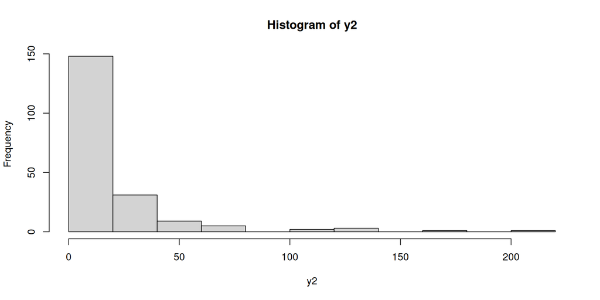

```r
hist(y2)
```

If we fit a Poisson regression to this negative-binomially distributed simulation $\textbf{y}_2$:

```r
(reg2 <- glm(y2 ~ x1 + x2, family = "poisson"))
```

```
##
## Call:  glm(formula = y2 ~ x1 + x2, family = "poisson")
##
## Coefficients:
## (Intercept)           x1           x2
##      1.2021       0.9243      -0.1267
##
## Degrees of Freedom: 199 Total (i.e. Null);  197 Residual
## Null Deviance:       5586
## Residual Deviance: 3679  AIC: 4430
```

and plot the residuals:

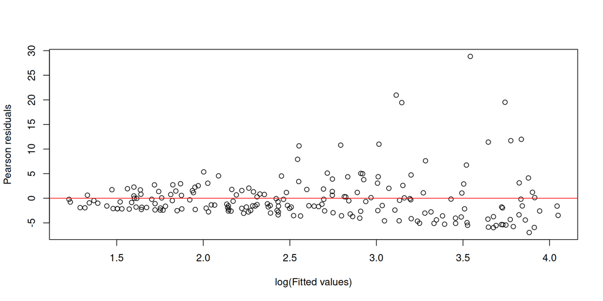

```r
plot(log(fitted(reg2)), residuals(reg2, type = "pearson"),
     xlab = "log(Fitted values)", ylab = "Pearson residuals")
abline(h = 0, col = "red")
```

we see that they look poor. Typically, when there is overdispersion present in the model, residuals will “fan out”, i.e., the spread increases with the fitted values (horizontal axis). This pattern is typical when there is an issue of overdispersion. Instead of looking at the residuals, and identifying overdispersion visually, we can also quantify the overdispersion with an overdispersion factor:

```r
deviance(reg2)/df.residual(reg2)
```

```
## [1] 18.67494
```

When this overdispersion factor is larger than 1, it is indicative of overdispersion, and provides another motivation for adjusting the model structure. Overdispersion biases the parameter estimates, and makes for too narrow confidence intervals. The `DHARMa` package, or the `performance` package have functions for testing overdispersion that can help you; the `testDispersion` and `check_overdispersion` functions, respectively.

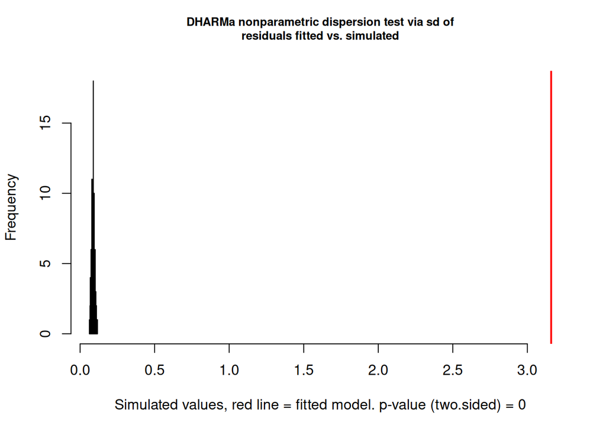

```
##
##  DHARMa nonparametric dispersion test via sd of residuals fitted vs.
##  simulated
##
## data:  simulationOutput
## dispersion = 36.301, p-value < 2.2e-16
## alternative hypothesis: two.sided
```

```r
DHARMa::testDispersion(reg2)
```

```r
performance::check_overdispersion(reg2)
```

```
## # Overdispersion test
##
##        dispersion ratio =   22.604
##   Pearson's Chi-Squared = 4452.960
##                 p-value =  < 0.001
```

```
## Overdispersion detected.
```

We can fit a negative-binomial regression, but we cannot do this with the `glm` function in R; we need the `glm.nb` function from the `MASS` package instead.

```r
(reg3 <- MASS::glm.nb(y2 ~ x1 + x2))
```

```
##
## Call:  MASS::glm.nb(formula = y2 ~ x1 + x2, init.theta = 0.9502526279,
##     link = log)
##
## Coefficients:
## (Intercept)           x1           x2
##      0.9818       1.0425      -0.1913
##
## Degrees of Freedom: 199 Total (i.e. Null);  197 Residual
## Null Deviance:       344.4
## Residual Deviance: 229.2     AIC: 1456
```

Overdispersion is always relative to the Poisson assumption, so it is not possible to have overdispersion in the negative-binomial model.

# Datasets

We will use different datasets than in the last practicals (except the Baseball example, that has both Poisson and Binomial variables!). You can find the datasets in the “data” folder of the github repository.

1. [Horseshoecrabs](https://raw.githubusercontent.com/BertvanderVeen/GLM-workshop/refs/heads/main/data/Horseshoecrabs.csv): Data on the number of male satellites attracted by female horseshoecrabs, data used in the presentation today.
2. [Roadkills](https://raw.githubusercontent.com/BertvanderVeen/GLM-workshop/refs/heads/main/data/RoadKills.csv): Count of amphibian road kills (TOT.n) as a function of distance to a park (D.PARK), and other variables of the parks such as the amount of olive grooves, montado with and without shrubs, shrubs, urban area, water reservoirs, dirt road length, paved road length, distance to water reservoirs, water courses, and more.
3. [Baseball](https://raw.githubusercontent.com/BertvanderVeen/GLM-workshop/refs/heads/main/data/Baseball.csv)
4. [Campus](https://raw.githubusercontent.com/BertvanderVeen/GLM-workshop/refs/heads/main/data/Campus.csv)
5. [Hurricanes](https://raw.githubusercontent.com/BertvanderVeen/GLM-workshop/refs/heads/main/data/hurricanes.csv)

# Part 1

Here is what I want you to do:

1. Pick a dataset and fit a Poisson regression. You can also do model selection as we did yesterday.
2. Examine the parameter estimates. Use `exp(coef(...))` to interpret them on the count scale. What does a one-unit change in a predictor mean for the expected count?
3. Examine the confidence intervals with `confint()`. You can also exponentiate them with `exp(confint(...))`. What conclusions can you draw about the effects?
4. Check the residuals, and test with the `DHARMa` or `performance` packages if there is overdispersion.

# Part 2

**Open after Part 1**

5. Fit a negative-binomial regression and check the residuals for improvement.
6. Compare the parameter estimates from both models. Have they changed?
7. Compare the confidence intervals. Have they gotten wider or narrower? What does this tell you about what overdispersion does to uncertainty in the Poisson model?
8. Has your overall conclusion about the effects changed?